# TravelPackage_RaviPotlachervu

## Travel Package Prediction by Ravi Potlachervu

### Background and Context

At tourism company named "Visit with us". The Policy Maker of the company wants to enable and establish a viable business model to expand the customer base.

A viable business model is a central concept that helps you to understand the existing ways of doing the business and how to change the ways for the benefit of the tourism sector.

One of the ways to expand the customer base is to introduce a new offering of packages.

Currently, there are 5 types of packages the company is offering - Basic, Standard, Deluxe, Super Deluxe, King. Looking at the data of the last year, we observed that 18% of the customers purchased the packages.

However, it was difficult to identify the potential customers because customers were contacted at random without looking at the available information.

The company is now planning to launch a new product i.e. Wellness Tourism Package. Wellness Tourism is defined as Travel that allows the traveler to maintain, enhance or kick-start a healthy lifestyle, and support or increase one's sense of well-being.

This time company wants to harness the available data of existing and potential customers to target the right customers.

As a Data Scientist at "Visit with us" travel company has to analyze the customers' data and information to provide recommendations to the Policy Maker and build a model to predict the potential customer who is going to purchase the newly introduced travel package. The model will be built to make predictions before a customer is contacted.

### Objective

To predict which customer is more likely to purchase the newly introduced travel package.

### Customer details:

- CustomerID: Unique customer ID
- ProdTaken: Whether the customer has purchased a package or not (0: No, 1: Yes)
- Age: Age of customer
- TypeofContact: How customer was contacted (Company Invited or Self Inquiry)
- CityTier: City tier depends on the development of a city, population, facilities, and living standards. The categories are ordered i.e. Tier 1 > Tier 2 > Tier 3. It's the city the customer lives in.
- Occupation: Occupation of customer
- Gender: Gender of customer
- NumberOfPersonVisiting: Total number of persons planning to take the trip with the customer
- PreferredPropertyStar: Preferred hotel property rating by customer
- vMaritalStatus: Marital status of customer
- NumberOfTrips: Average number of trips in a year by customer
- Passport: The customer has a passport or not (0: No, 1: Yes)
- OwnCar: Whether the customers own a car or not (0: No, 1: Yes)
- NumberOfChildrenVisiting: Total number of children with age less than 5 planning to take the trip with the customer
- Designation: Designation of the customer in the current organization
- MonthlyIncome: Gross monthly income of the customer

### Customer interaction data:

- PitchSatisfactionScore: Sales pitch satisfaction score
- ProductPitched: Product pitched by the salesperson
- NumberOfFollowups: Total number of follow-ups has been done by the salesperson after the sales pitch
- DurationOfPitch: Duration of the pitch by a salesperson to the customer

```python
#install required packages xgboost is not part Anaconda by default. Here we will install xgboost package.
!pip install xgboost
```

```
     |████████████████████████████████| 1.7 MB 2.6 MB/s eta 0:00:01
```

### Import necessary libraries

```python
# Library to suppress warnings or deprecation notes
import warnings
warnings.filterwarnings('ignore')

# Libraries to help with reading and manipulating data
import numpy as np
import pandas as pd

# Libraries to help with data visualization
import matplotlib.pyplot as plt
%matplotlib inline
import seaborn as sns

# Libraries to split data, impute missing values
from sklearn.model_selection import train_test_split
from sklearn.impute import SimpleImputer

# Libraries to import decision tree classifier and different ensemble classifiers
from sklearn.ensemble import BaggingClassifier
from sklearn.ensemble import RandomForestClassifier
from sklearn.ensemble import AdaBoostClassifier, GradientBoostingClassifier
from xgboost import XGBClassifier
from sklearn.ensemble import StackingClassifier
from sklearn.tree import DecisionTreeClassifier

# Libtune to tune model, get different metric scores
from sklearn import metrics
from sklearn.metrics import confusion_matrix, classification_report, accuracy_score, precision_score, recall_score, f1_score, roc_auc_score
from sklearn.model_selection import GridSearchCV
warnings.filterwarnings('ignore')
```

### Read the dataset

```python
df=pd.read_csv("Tourism.csv")
```

```python
# copying data to another varaible to avoid any changes to original data
data=df.copy()
```

### View the first and last 5 rows of the dataset.

```python
data.head()
```

|  | CustomerID | ProdTaken | Age | TypeofContact | CityTier | DurationOfPitch | Occupation | Gender | NumberOfPersonVisiting | NumberOfFollowups | ProductPitched | PreferredPropertyStar | MaritalStatus | NumberOfTrips | Passport | PitchSatisfactionScore | OwnCar | NumberOfChildrenVisiting | Designation | MonthlyIncome |
| --- | --- | --- | --- | --- | --- | --- | --- | --- | --- | --- | --- | --- | --- | --- | --- | --- | --- | --- | --- | --- |
| 0 | 200000 | 1 | 41.0 | Self Enquiry | 3 | 6.0 | Salaried | Female | 3 | 3.0 | Deluxe | 3.0 | Single | 1.0 | 1 | 2 | 1 | 0.0 | Manager | 20993.0 |
| 1 | 200001 | 0 | 49.0 | Company Invited | 1 | 14.0 | Salaried | Male | 3 | 4.0 | Deluxe | 4.0 | Divorced | 2.0 | 0 | 3 | 1 | 2.0 | Manager | 20130.0 |
| 2 | 200002 | 1 | 37.0 | Self Enquiry | 1 | 8.0 | Free Lancer | Male | 3 | 4.0 | Basic | 3.0 | Single | 7.0 | 1 | 3 | 0 | 0.0 | Executive | 17090.0 |
| 3 | 200003 | 0 | 33.0 | Company Invited | 1 | 9.0 | Salaried | Female | 2 | 3.0 | Basic | 3.0 | Divorced | 2.0 | 1 | 5 | 1 | 1.0 | Executive | 17909.0 |
| 4 | 200004 | 0 | NaN | Self Enquiry | 1 | 8.0 | Small Business | Male | 2 | 3.0 | Basic | 4.0 | Divorced | 1.0 | 0 | 5 | 1 | 0.0 | Executive | 18468.0 |

```python
data.tail()
```

|  | CustomerID | ProdTaken | Age | TypeofContact | CityTier | DurationOfPitch | Occupation | Gender | NumberOfPersonVisiting | NumberOfFollowups | ProductPitched | PreferredPropertyStar | MaritalStatus | NumberOfTrips | Passport | PitchSatisfactionScore | OwnCar | NumberOfChildrenVisiting | Designation | MonthlyIncome |
| --- | --- | --- | --- | --- | --- | --- | --- | --- | --- | --- | --- | --- | --- | --- | --- | --- | --- | --- | --- | --- |
| 4883 | 204883 | 1 | 49.0 | Self Enquiry | 3 | 9.0 | Small Business | Male | 3 | 5.0 | Deluxe | 4.0 | Unmarried | 2.0 | 1 | 1 | 1 | 1.0 | Manager | 26576.0 |
| 4884 | 204884 | 1 | 28.0 | Company Invited | 1 | 31.0 | Salaried | Male | 4 | 5.0 | Basic | 3.0 | Single | 3.0 | 1 | 3 | 1 | 2.0 | Executive | 21212.0 |
| 4885 | 204885 | 1 | 52.0 | Self Enquiry | 3 | 17.0 | Salaried | Female | 4 | 4.0 | Standard | 4.0 | Married | 7.0 | 0 | 1 | 1 | 3.0 | Senior Manager | 31820.0 |
| 4886 | 204886 | 1 | 19.0 | Self Enquiry | 3 | 16.0 | Small Business | Male | 3 | 4.0 | Basic | 3.0 | Single | 3.0 | 0 | 5 | 0 | 2.0 | Executive | 20289.0 |
| 4887 | 204887 | 1 | 36.0 | Self Enquiry | 1 | 14.0 | Salaried | Male | 4 | 4.0 | Basic | 4.0 | Unmarried | 3.0 | 1 | 3 | 1 | 2.0 | Executive | 24041.0 |

### Understand the shape of the dataset.

```python
data.shape
```

```
(4888, 20)
```

- The dataset has 4888 rows and 20 columns of data

### Check the data types of the columns for the dataset.

```python
data.info()
```

```
<class 'pandas.core.frame.DataFrame'>
RangeIndex: 4888 entries, 0 to 4887
Data columns (total 20 columns):
 #   Column                    Non-Null Count  Dtype
---  ------                    --------------  -----
 0   CustomerID                4888 non-null   int64
 1   ProdTaken                 4888 non-null   int64
 2   Age                       4662 non-null   float64
 3   TypeofContact             4863 non-null   object
 4   CityTier                  4888 non-null   int64
 5   DurationOfPitch           4637 non-null   float64
 6   Occupation                4888 non-null   object
 7   Gender                    4888 non-null   object
 8   NumberOfPersonVisiting    4888 non-null   int64
 9   NumberOfFollowups         4843 non-null   float64
 10  ProductPitched            4888 non-null   object
 11  PreferredPropertyStar     4862 non-null   float64
 12  MaritalStatus             4888 non-null   object
 13  NumberOfTrips             4748 non-null   float64
 14  Passport                  4888 non-null   int64
 15  PitchSatisfactionScore    4888 non-null   int64
 16  OwnCar                    4888 non-null   int64
 17  NumberOfChildrenVisiting  4822 non-null   float64
 18  Designation               4888 non-null   object
 19  MonthlyIncome             4655 non-null   float64
dtypes: float64(7), int64(7), object(6)
memory usage: 763.9+ KB
```

**Observations -**

- There are several null values in the dataset.
- We can convert the object type columns to categories.
- 'ProdTaken','OwnCar','Passport','CityTier' are currrently set to numerical datatypes, we will convert these to Categorical variables.

`converting "objects" to "category" reduces the data space required to store the dataframe`

### Fixing the data types

```python
# Convert object variables to Categorical variables
cat_cols = ['TypeofContact', 'Occupation', 'Gender', 'ProductPitched',
       'MaritalStatus', 'Designation','ProdTaken','OwnCar','Passport','CityTier']
for i in cat_cols:
    data[i] = data[i].astype('category')
```

```python
data.info()
```

```
<class 'pandas.core.frame.DataFrame'>
RangeIndex: 4888 entries, 0 to 4887
Data columns (total 20 columns):
 #   Column                    Non-Null Count  Dtype
---  ------                    --------------  -----
 0   CustomerID                4888 non-null   int64
 1   ProdTaken                 4888 non-null   category
 2   Age                       4662 non-null   float64
 3   TypeofContact             4863 non-null   category
 4   CityTier                  4888 non-null   category
 5   DurationOfPitch           4637 non-null   float64
 6   Occupation                4888 non-null   category
 7   Gender                    4888 non-null   category
 8   NumberOfPersonVisiting    4888 non-null   int64
 9   NumberOfFollowups         4843 non-null   float64
 10  ProductPitched            4888 non-null   category
 11  PreferredPropertyStar     4862 non-null   float64
 12  MaritalStatus             4888 non-null   category
 13  NumberOfTrips             4748 non-null   float64
 14  Passport                  4888 non-null   category
 15  PitchSatisfactionScore    4888 non-null   int64
 16  OwnCar                    4888 non-null   category
 17  NumberOfChildrenVisiting  4822 non-null   float64
 18  Designation               4888 non-null   category
 19  MonthlyIncome             4655 non-null   float64
dtypes: category(10), float64(7), int64(3)
memory usage: 431.3 KB
```

`we can see that the memory usage has decreased from 763 KB to 431 KB`, this technique is generally useful for bigger datasets.

### Summary of the dataset.

```python
data.describe().T
```

|  | count | mean | std | min | 25% | 50% | 75% | max |
| --- | --- | --- | --- | --- | --- | --- | --- | --- |
| CustomerID | 4888.0 | 202443.500000 | 1411.188388 | 200000.0 | 201221.75 | 202443.5 | 203665.25 | 204887.0 |
| Age | 4662.0 | 37.622265 | 9.316387 | 18.0 | 31.00 | 36.0 | 44.00 | 61.0 |
| DurationOfPitch | 4637.0 | 15.490835 | 8.519643 | 5.0 | 9.00 | 13.0 | 20.00 | 127.0 |
| NumberOfPersonVisiting | 4888.0 | 2.905074 | 0.724891 | 1.0 | 2.00 | 3.0 | 3.00 | 5.0 |
| NumberOfFollowups | 4843.0 | 3.708445 | 1.002509 | 1.0 | 3.00 | 4.0 | 4.00 | 6.0 |
| PreferredPropertyStar | 4862.0 | 3.581037 | 0.798009 | 3.0 | 3.00 | 3.0 | 4.00 | 5.0 |
| NumberOfTrips | 4748.0 | 3.236521 | 1.849019 | 1.0 | 2.00 | 3.0 | 4.00 | 22.0 |
| PitchSatisfactionScore | 4888.0 | 3.078151 | 1.365792 | 1.0 | 2.00 | 3.0 | 4.00 | 5.0 |
| NumberOfChildrenVisiting | 4822.0 | 1.187267 | 0.857861 | 0.0 | 1.00 | 1.0 | 2.00 | 3.0 |
| MonthlyIncome | 4655.0 | 23619.853491 | 5380.698361 | 1000.0 | 20346.00 | 22347.0 | 25571.00 | 98678.0 |

```python
data.describe(include=['category']).T
```

|  | count | unique | top | freq |
| --- | --- | --- | --- | --- |
| ProdTaken | 4888 | 2 | 0 | 3968 |
| TypeofContact | 4863 | 2 | Self Enquiry | 3444 |
| CityTier | 4888 | 3 | 1 | 3190 |
| Occupation | 4888 | 4 | Salaried | 2368 |
| Gender | 4888 | 3 | Male | 2916 |
| ProductPitched | 4888 | 5 | Basic | 1842 |
| MaritalStatus | 4888 | 4 | Married | 2340 |
| Passport | 4888 | 2 | 0 | 3466 |
| OwnCar | 4888 | 2 | 1 | 3032 |
| Designation | 4888 | 5 | Executive | 1842 |

```python
#Check for duplicate values.
data.duplicated().sum()
```

```
0
```

- No duplicate values are present in the dataset

### Data preprocessing

**Dropping columns which are not adding any information.**

```python
data.drop(['CustomerID'],axis=1,inplace=True)
```

**Let's look at the unqiue values of all the categories**

```python
cols_cat= data.select_dtypes(['category'])
```

```python
for i in cols_cat.columns:
    print('Unique values in',i, 'are :')
    print(cols_cat[i].value_counts())
    print('*'*50)
```

```
Unique values in ProdTaken are :
0    3968
1     920
Name: ProdTaken, dtype: int64
Unique values in TypeofContact are :
Self Enquiry       3444
Company Invited    1419
Name: TypeofContact, dtype: int64
Unique values in CityTier are :
1    3190
3    1500
2     198
Name: CityTier, dtype: int64
Unique values in Occupation are :
Salaried          2368
Small Business    2084
Large Business     434
Free Lancer          2
Name: Occupation, dtype: int64
Unique values in Gender are :
Male       2916
Female     1817
Fe Male     155
Name: Gender, dtype: int64
Unique values in ProductPitched are :
Basic           1842
Deluxe          1732
Standard         742
Super Deluxe     342
King             230
Name: ProductPitched, dtype: int64
Unique values in MaritalStatus are :
Married      2340
Divorced      950
Single        916
Unmarried     682
Name: MaritalStatus, dtype: int64
Unique values in Passport are :
0    3466
1    1422
Name: Passport, dtype: int64
Unique values in OwnCar are :
1    3032
0    1856
Name: OwnCar, dtype: int64
Unique values in Designation are :
Executive         1842
Manager           1732
Senior Manager     742
AVP                342
VP                 230
Name: Designation, dtype: int64
```

- There is discrepency on Gender column Female and Fe male two categories, we will fix 'Fe male' entries.

```python
#Fix Fe male gender category value
data['Gender'] = data['Gender'].str.replace('Fe Male','Female')
```

```python
data.Gender.value_counts()
```

```
Male      2916
Female    1972
Name: Gender, dtype: int64
```

```python
data.isnull().sum()
```

```
ProdTaken                     0
Age                         226
TypeofContact                25
CityTier                      0
DurationOfPitch             251
Occupation                    0
Gender                        0
NumberOfPersonVisiting        0
NumberOfFollowups            45
ProductPitched                0
PreferredPropertyStar        26
MaritalStatus                 0
NumberOfTrips               140
Passport                      0
PitchSatisfactionScore        0
OwnCar                        0
NumberOfChildrenVisiting     66
Designation                   0
MonthlyIncome               233
dtype: int64
```

- There are missing values in 8 columns of the data.
- We will treat these missing values after understanding the distributions of features in the data, the relationships that exist in the data. This will help us impute these values more effectively.

```python
# data.shape[0] will give us the number of rows in the dataset
# selecting the instances where missing value is greater than 0
pd.DataFrame({'Count':data.isnull().sum()[data.isnull().sum()>0],'Percentage':(data.isnull().sum()[data.isnull().sum()>0]/data.shape[0])*100})
```

|  | Count | Percentage |
| --- | --- | --- |
| Age | 226 | 4.623568 |
| TypeofContact | 25 | 0.511457 |
| DurationOfPitch | 251 | 5.135025 |
| NumberOfFollowups | 45 | 0.920622 |
| PreferredPropertyStar | 26 | 0.531915 |
| NumberOfTrips | 140 | 2.864157 |
| NumberOfChildrenVisiting | 66 | 1.350245 |
| MonthlyIncome | 233 | 4.766776 |

### Imputing "Age" missing values

- We will impute Age values using 'Designation, Gender and MaritalStatus

```python
# extracting all the information of other variables where Age is null
data.loc[data['Age'].isnull()==True]
```

|  | ProdTaken | Age | TypeofContact | CityTier | DurationOfPitch | Occupation | Gender | NumberOfPersonVisiting | NumberOfFollowups | ProductPitched | PreferredPropertyStar | MaritalStatus | NumberOfTrips | Passport | PitchSatisfactionScore | OwnCar | NumberOfChildrenVisiting | Designation | MonthlyIncome |
| --- | --- | --- | --- | --- | --- | --- | --- | --- | --- | --- | --- | --- | --- | --- | --- | --- | --- | --- | --- |
| 4 | 0 | NaN | Self Enquiry | 1 | 8.0 | Small Business | Male | 2 | 3.0 | Basic | 4.0 | Divorced | 1.0 | 0 | 5 | 1 | 0.0 | Executive | 18468.0 |
| 11 | 0 | NaN | Self Enquiry | 1 | 21.0 | Salaried | Female | 2 | 4.0 | Deluxe | 3.0 | Single | 1.0 | 1 | 3 | 0 | 0.0 | Manager | NaN |
| 19 | 0 | NaN | Self Enquiry | 1 | 8.0 | Salaried | Male | 2 | 3.0 | Basic | 3.0 | Single | 6.0 | 1 | 4 | 0 | 1.0 | Executive | NaN |
| 20 | 0 | NaN | Company Invited | 1 | 17.0 | Salaried | Female | 3 | 2.0 | Deluxe | 3.0 | Married | 1.0 | 0 | 3 | 1 | 2.0 | Manager | NaN |
| 21 | 1 | NaN | Self Enquiry | 3 | 15.0 | Salaried | Male | 2 | 4.0 | Deluxe | 5.0 | Single | 1.0 | 0 | 2 | 0 | 0.0 | Manager | 18407.0 |
| ... | ... | ... | ... | ... | ... | ... | ... | ... | ... | ... | ... | ... | ... | ... | ... | ... | ... | ... | ... |
| 2410 | 1 | NaN | Self Enquiry | 1 | 30.0 | Small Business | Male | 2 | 3.0 | Basic | 4.0 | Married | 2.0 | 1 | 1 | 0 | 0.0 | Executive | NaN |
| 2413 | 1 | NaN | Self Enquiry | 3 | 21.0 | Small Business | Male | 2 | 5.0 | Deluxe | 3.0 | Married | 7.0 | 1 | 1 | 0 | 1.0 | Manager | 18423.0 |
| 2427 | 1 | NaN | Self Enquiry | 3 | 22.0 | Small Business | Male | 3 | 3.0 | Standard | 3.0 | Married | 3.0 | 0 | 5 | 0 | 1.0 | Senior Manager | 18544.0 |
| 2430 | 1 | NaN | Self Enquiry | 1 | 14.0 | Small Business | Female | 3 | 3.0 | Basic | 5.0 | Married | 2.0 | 1 | 3 | 0 | 2.0 | Executive | NaN |
| 2435 | 1 | NaN | Self Enquiry | 2 | 26.0 | Small Business | Female | 3 | 3.0 | Basic | 4.0 | Married | 1.0 | 1 | 3 | 0 | 1.0 | Executive | 18669.0 |

226 rows × 19 columns

```python
#grouping data on region and type of property
# finding the median of landsize for each group and imputing the missing data with it
data['Age'] = data['Age'].fillna(value = data.groupby(["Designation", "Gender","MaritalStatus"])['Age'].transform('median'))
```

```python
data[data["Age"].isnull()]
```

|  | ProdTaken | Age | TypeofContact | CityTier | DurationOfPitch | Occupation | Gender | NumberOfPersonVisiting | NumberOfFollowups | ProductPitched | PreferredPropertyStar | MaritalStatus | NumberOfTrips | Passport | PitchSatisfactionScore | OwnCar | NumberOfChildrenVisiting | Designation | MonthlyIncome |
| --- | --- | --- | --- | --- | --- | --- | --- | --- | --- | --- | --- | --- | --- | --- | --- | --- | --- | --- | --- |

- Imputed Age null values with median value

### Imputing "TypeofContact" missing values

```python
data['TypeofContact'].value_counts()
```

```
Self Enquiry       3444
Company Invited    1419
Name: TypeofContact, dtype: int64
```

- Majority of values of TypeofContact are self enquiry. As it is categorical variable we will impute null using Mode with more frequent values in this case "Self Enquiry".

```python
data['TypeofContact'].mode()
```

```
0    Self Enquiry
Name: TypeofContact, dtype: category
Categories (2, object): ['Company Invited', 'Self Enquiry']
```

```python
data['TypeofContact']=data['TypeofContact'].fillna('Self Enquiry')
```

```python
data[data["TypeofContact"].isnull()]
```

|  | ProdTaken | Age | TypeofContact | CityTier | DurationOfPitch | Occupation | Gender | NumberOfPersonVisiting | NumberOfFollowups | ProductPitched | PreferredPropertyStar | MaritalStatus | NumberOfTrips | Passport | PitchSatisfactionScore | OwnCar | NumberOfChildrenVisiting | Designation | MonthlyIncome |
| --- | --- | --- | --- | --- | --- | --- | --- | --- | --- | --- | --- | --- | --- | --- | --- | --- | --- | --- | --- |

- Imputed "TypeofContact" missing values with Mode.

### Imputing "DurationofPitch" missing values

- We will impute DurationofPitch values using ProductPitched and NumberOfFollowups.

```python
data.loc[data['DurationOfPitch'].isnull()==True]
```

|  | ProdTaken | Age | TypeofContact | CityTier | DurationOfPitch | Occupation | Gender | NumberOfPersonVisiting | NumberOfFollowups | ProductPitched | PreferredPropertyStar | MaritalStatus | NumberOfTrips | Passport | PitchSatisfactionScore | OwnCar | NumberOfChildrenVisiting | Designation | MonthlyIncome |
| --- | --- | --- | --- | --- | --- | --- | --- | --- | --- | --- | --- | --- | --- | --- | --- | --- | --- | --- | --- |
| 46 | 0 | 34.0 | Company Invited | 3 | NaN | Small Business | Male | 3 | 3.0 | Deluxe | 3.0 | Single | 1.0 | 0 | 5 | 1 | 1.0 | Manager | 19568.0 |
| 75 | 0 | 31.0 | Self Enquiry | 1 | NaN | Salaried | Female | 3 | 3.0 | Deluxe | 3.0 | Single | 2.0 | 0 | 5 | 0 | 1.0 | Manager | NaN |
| 76 | 0 | 35.0 | Self Enquiry | 3 | NaN | Small Business | Male | 2 | 4.0 | Deluxe | 5.0 | Single | 1.0 | 0 | 2 | 0 | 1.0 | Manager | NaN |
| 84 | 0 | 34.0 | Self Enquiry | 1 | NaN | Small Business | Male | 3 | 3.0 | Deluxe | 4.0 | Divorced | 2.0 | 0 | 5 | 0 | 0.0 | Manager | NaN |
| 103 | 0 | 34.0 | Self Enquiry | 1 | NaN | Salaried | Female | 2 | 3.0 | Deluxe | 3.0 | Single | 2.0 | 0 | 3 | 1 | 0.0 | Manager | 19809.0 |
| ... | ... | ... | ... | ... | ... | ... | ... | ... | ... | ... | ... | ... | ... | ... | ... | ... | ... | ... | ... |
| 4215 | 0 | 19.0 | Self Enquiry | 3 | NaN | Small Business | Female | 4 | 5.0 | Basic | 3.0 | Single | 3.0 | 0 | 1 | 0 | 3.0 | Executive | 19878.0 |
| 4427 | 1 | 21.0 | Self Enquiry | 1 | NaN | Small Business | Male | 3 | 4.0 | Basic | 3.0 | Single | 3.0 | 1 | 5 | 1 | 2.0 | Executive | 19687.0 |
| 4641 | 0 | 19.0 | Company Invited | 1 | NaN | Salaried | Male | 4 | 4.0 | Basic | 3.0 | Single | 3.0 | 0 | 1 | 0 | 2.0 | Executive | 19729.0 |
| 4678 | 0 | 29.0 | Self Enquiry | 3 | NaN | Small Business | Male | 4 | 4.0 | Basic | 4.0 | Married | 3.0 | 0 | 5 | 0 | 3.0 | Executive | 19730.0 |
| 4825 | 1 | 26.0 | Self Enquiry | 1 | NaN | Salaried | Male | 3 | 4.0 | Basic | 5.0 | Married | 6.0 | 0 | 5 | 1 | 1.0 | Executive | 19796.0 |

251 rows × 19 columns

```python
data.groupby(['ProductPitched','NumberOfFollowups'])[['DurationOfPitch']].median()
```

| ProductPitched | NumberOfFollowups | DurationOfPitch |
| --- | --- | --- |
| Basic | 1.0 | 14.0 |
|  | 2.0 | 15.0 |
|  | 3.0 | 13.0 |
|  | 4.0 | 13.0 |
|  | 5.0 | 12.0 |
|  | 6.0 | 15.5 |
| Deluxe | 1.0 | 11.5 |
|  | 2.0 | 13.0 |
|  | 3.0 | 14.0 |
|  | 4.0 | 15.0 |
|  | 5.0 | 13.0 |
|  | 6.0 | 13.0 |
| King | 1.0 | 15.0 |
|  | 2.0 | 15.5 |
|  | 3.0 | 10.0 |
|  | 4.0 | 11.0 |
|  | 5.0 | 10.0 |
|  | 6.0 | 9.0 |
| Standard | 1.0 | 14.0 |
|  | 2.0 | 15.0 |
|  | 3.0 | 14.0 |
|  | 4.0 | 14.0 |
|  | 5.0 | 14.0 |
|  | 6.0 | 14.0 |
| Super Deluxe | 1.0 | 12.5 |
|  | 2.0 | 13.0 |
|  | 3.0 | 13.0 |
|  | 4.0 | 12.5 |
|  | 5.0 | 13.0 |
|  | 6.0 | 16.0 |

- As we see DurationofPitch is influenced by ProductPitched and Numberoffollowup. We will impute DurationofPitch by median group by ProductPitched and NumberofFollowups.

```python
data['DurationOfPitch'] = data['DurationOfPitch'].fillna(value = data.groupby(['ProductPitched','NumberOfFollowups'])['DurationOfPitch'].transform('median'))
```

```python
data.loc[data['DurationOfPitch'].isnull()==True]
```

|  | ProdTaken | Age | TypeofContact | CityTier | DurationOfPitch | Occupation | Gender | NumberOfPersonVisiting | NumberOfFollowups | ProductPitched | PreferredPropertyStar | MaritalStatus | NumberOfTrips | Passport | PitchSatisfactionScore | OwnCar | NumberOfChildrenVisiting | Designation | MonthlyIncome |
| --- | --- | --- | --- | --- | --- | --- | --- | --- | --- | --- | --- | --- | --- | --- | --- | --- | --- | --- | --- |

- Imputed DurationOfPitch missing values by median.

### Imputing "NumberOfFollowups" missing values

- We will impute NumberOfFollowups values using Gender and ProductPitched

```python
data.loc[data['NumberOfFollowups'].isnull()==True]
```

|  | ProdTaken | Age | TypeofContact | CityTier | DurationOfPitch | Occupation | Gender | NumberOfPersonVisiting | NumberOfFollowups | ProductPitched | PreferredPropertyStar | MaritalStatus | NumberOfTrips | Passport | PitchSatisfactionScore | OwnCar | NumberOfChildrenVisiting | Designation | MonthlyIncome |
| --- | --- | --- | --- | --- | --- | --- | --- | --- | --- | --- | --- | --- | --- | --- | --- | --- | --- | --- | --- |
| 79 | 0 | 46.0 | Self Enquiry | 2 | 11.0 | Small Business | Male | 3 | NaN | Deluxe | 4.0 | Married | 1.0 | 1 | 5 | 0 | 1.0 | Manager | 20021.0 |
| 94 | 0 | 32.0 | Self Enquiry | 3 | 12.0 | Small Business | Male | 2 | NaN | Deluxe | 3.0 | Single | 2.0 | 0 | 5 | 1 | 0.0 | Manager | 20010.0 |
| 96 | 0 | 24.0 | Self Enquiry | 3 | 9.0 | Salaried | Female | 2 | NaN | Deluxe | 3.0 | Divorced | 1.0 | 0 | 4 | 1 | 0.0 | Manager | 19999.0 |
| 122 | 1 | 56.0 | Self Enquiry | 1 | 20.0 | Salaried | Female | 3 | NaN | Basic | 4.0 | Divorced | 1.0 | 1 | 5 | 1 | 1.0 | Executive | 19963.0 |
| 135 | 0 | 36.0 | Self Enquiry | 1 | 12.0 | Small Business | Male | 2 | NaN | Deluxe | 4.0 | Married | 7.0 | 0 | 4 | 1 | 1.0 | Manager | 19941.0 |
| 174 | 0 | 45.0 | Self Enquiry | 3 | 10.0 | Salaried | Female | 1 | NaN | Deluxe | 5.0 | Married | 5.0 | 1 | 4 | 0 | 0.0 | Manager | 20006.0 |
| 317 | 1 | 52.0 | Self Enquiry | 1 | 14.0 | Small Business | Male | 2 | NaN | Deluxe | 4.0 | Divorced | 3.0 | 0 | 2 | 1 | 1.0 | Manager | 19941.0 |
| 322 | 0 | 32.0 | Self Enquiry | 1 | 8.0 | Small Business | Female | 3 | NaN | Deluxe | 3.0 | Single | 1.0 | 0 | 3 | 1 | 2.0 | Manager | 20055.0 |
| 376 | 0 | 51.0 | Self Enquiry | 3 | 20.0 | Salaried | Female | 2 | NaN | Deluxe | 3.0 | Divorced | 5.0 | 0 | 3 | 0 | 1.0 | Manager | 19936.0 |
| 532 | 0 | 47.0 | Self Enquiry | 3 | 20.0 | Small Business | Male | 2 | NaN | Deluxe | 5.0 | Single | 3.0 | 0 | 2 | 0 | 1.0 | Manager | 19960.0 |
| 629 | 0 | 28.0 | Self Enquiry | 2 | 14.0 | Small Business | Male | 3 | NaN | Basic | 3.0 | Married | 2.0 | 0 | 2 | 0 | 1.0 | Executive | 19936.0 |
| 737 | 0 | 41.0 | Self Enquiry | 1 | 13.0 | Small Business | Female | 2 | NaN | Deluxe | 3.0 | Single | 7.0 | 0 | 3 | 1 | 0.0 | Manager | 20003.0 |
| 748 | 1 | 26.0 | Company Invited | 3 | 35.0 | Small Business | Male | 3 | NaN | Deluxe | 5.0 | Single | 1.0 | 0 | 3 | 0 | 0.0 | Manager | 19969.0 |
| 820 | 0 | 35.0 | Company Invited | 3 | 17.0 | Small Business | Male | 2 | NaN | Deluxe | 3.0 | Married | 2.0 | 0 | 5 | 0 | 0.0 | Manager | 19968.0 |
| 881 | 0 | 32.0 | Company Invited | 1 | 8.0 | Salaried | Female | 2 | NaN | Deluxe | 3.0 | Single | 5.0 | 1 | 5 | 1 | 1.0 | Manager | 19998.0 |
| 885 | 0 | 25.0 | Self Enquiry | 3 | 16.0 | Salaried | Male | 2 | NaN | Deluxe | 3.0 | Single | 1.0 | 0 | 2 | 0 | 1.0 | Manager | 19950.0 |
| 1159 | 0 | 39.0 | Company Invited | 1 | 10.0 | Small Business | Female | 2 | NaN | Deluxe | 3.0 | Single | 1.0 | 0 | 3 | 1 | 0.0 | Manager | 20042.0 |
| 1215 | 0 | 35.0 | Company Invited | 1 | 8.0 | Small Business | Male | 3 | NaN | Basic | 3.0 | Single | 1.0 | 1 | 3 | 1 | 0.0 | Executive | 19930.0 |
| 1234 | 0 | 47.0 | Company Invited | 3 | 8.0 | Small Business | Male | 2 | NaN | Deluxe | 4.0 | Married | 1.0 | 0 | 1 | 0 | 1.0 | Manager | 19978.0 |
| 1244 | 0 | 30.0 | Company Invited | 1 | 8.0 | Large Business | Female | 3 | NaN | Basic | 5.0 | Single | 1.0 | 0 | 3 | 0 | 1.0 | Executive | 19968.0 |
| 1352 | 0 | 44.0 | Self Enquiry | 1 | 6.0 | Salaried | Male | 3 | NaN | Deluxe | 5.0 | Married | 3.0 | 0 | 3 | 1 | 2.0 | Manager | 20033.0 |
| 1389 | 0 | 31.0 | Company Invited | 1 | 6.0 | Salaried | Male | 2 | NaN | Deluxe | 5.0 | Married | 2.0 | 0 | 1 | 1 | 1.0 | Manager | 20003.0 |
| 1549 | 0 | 46.0 | Self Enquiry | 2 | 11.0 | Small Business | Male | 3 | NaN | Deluxe | 4.0 | Married | 1.0 | 1 | 5 | 1 | 2.0 | Manager | 20021.0 |
| 1564 | 0 | 32.0 | Self Enquiry | 3 | 12.0 | Small Business | Male | 2 | NaN | Deluxe | 3.0 | Single | 2.0 | 0 | 5 | 1 | 1.0 | Manager | 20010.0 |
| 1566 | 0 | 24.0 | Self Enquiry | 3 | 9.0 | Salaried | Female | 2 | NaN | Deluxe | 3.0 | Married | 1.0 | 0 | 4 | 0 | 0.0 | Manager | 19999.0 |
| 1592 | 1 | 56.0 | Self Enquiry | 1 | 20.0 | Salaried | Female | 3 | NaN | Basic | 4.0 | Married | 1.0 | 1 | 5 | 1 | 0.0 | Executive | 19963.0 |
| 1605 | 0 | 36.0 | Self Enquiry | 1 | 12.0 | Small Business | Male | 2 | NaN | Deluxe | 4.0 | Married | 7.0 | 0 | 4 | 0 | 1.0 | Manager | 19941.0 |
| 1644 | 0 | 45.0 | Self Enquiry | 3 | 10.0 | Salaried | Female | 1 | NaN | Deluxe | 5.0 | Married | 5.0 | 1 | 4 | 0 | 0.0 | Manager | 20006.0 |
| 1787 | 1 | 52.0 | Self Enquiry | 1 | 14.0 | Small Business | Male | 2 | NaN | Deluxe | 4.0 | Married | 3.0 | 0 | 1 | 1 | 0.0 | Manager | 19941.0 |
| 1846 | 0 | 51.0 | Self Enquiry | 3 | 20.0 | Salaried | Female | 2 | NaN | Deluxe | 3.0 | Married | 5.0 | 0 | 3 | 1 | 0.0 | Manager | 19936.0 |
| 2002 | 0 | 47.0 | Self Enquiry | 3 | 20.0 | Small Business | Male | 2 | NaN | Deluxe | 5.0 | Single | 3.0 | 0 | 1 | 1 | 1.0 | Manager | 19960.0 |
| 2099 | 0 | 28.0 | Self Enquiry | 2 | 14.0 | Small Business | Male | 3 | NaN | Basic | 3.0 | Married | 2.0 | 0 | 1 | 1 | 0.0 | Executive | 19936.0 |
| 2129 | 0 | 28.0 | Self Enquiry | 3 | 11.0 | Small Business | Male | 3 | NaN | Deluxe | 3.0 | Single | 2.0 | 0 | 3 | 0 | 1.0 | Manager | 19908.0 |
| 2207 | 0 | 41.0 | Self Enquiry | 1 | 13.0 | Small Business | Female | 2 | NaN | Deluxe | 3.0 | Single | 7.0 | 0 | 3 | 1 | 1.0 | Manager | 20003.0 |
| 2218 | 1 | 26.0 | Company Invited | 3 | 35.0 | Small Business | Male | 3 | NaN | Deluxe | 5.0 | Single | 1.0 | 0 | 3 | 1 | 1.0 | Manager | 19969.0 |
| 2290 | 0 | 35.0 | Company Invited | 3 | 17.0 | Small Business | Male | 2 | NaN | Deluxe | 3.0 | Married | 2.0 | 0 | 5 | 1 | 1.0 | Manager | 19968.0 |
| 2351 | 0 | 32.0 | Company Invited | 1 | 8.0 | Salaried | Female | 2 | NaN | Deluxe | 3.0 | Single | 5.0 | 1 | 5 | 1 | 0.0 | Manager | 19998.0 |
| 2355 | 0 | 25.0 | Self Enquiry | 3 | 16.0 | Salaried | Male | 2 | NaN | Deluxe | 3.0 | Single | 1.0 | 0 | 1 | 1 | 0.0 | Manager | 19950.0 |
| 2467 | 0 | 22.0 | Self Enquiry | 1 | 22.0 | Salaried | Male | 4 | NaN | Basic | 3.0 | Single | 3.0 | 0 | 3 | 1 | 2.0 | Executive | 19910.0 |
| 2959 | 0 | 36.0 | Company Invited | 1 | 10.0 | Salaried | Male | 3 | NaN | Basic | 3.0 | Divorced | 3.0 | 0 | 2 | 1 | 2.0 | Executive | 19959.0 |
| 3456 | 1 | 32.0 | Company Invited | 3 | 7.0 | Salaried | Female | 3 | NaN | Basic | 3.0 | Single | 3.0 | 0 | 3 | 1 | 2.0 | Executive | 20037.0 |
| 3460 | 1 | 32.0 | Self Enquiry | 1 | 15.0 | Salaried | Female | 3 | NaN | Basic | 4.0 | Single | 3.0 | 0 | 4 | 0 | 2.0 | Executive | 19939.0 |
| 3496 | 0 | 31.0 | Company Invited | 1 | 14.0 | Large Business | Male | 4 | NaN | Basic | 3.0 | Married | 3.0 | 0 | 5 | 0 | 1.0 | Executive | 19952.0 |
| 3937 | 0 | 22.0 | Self Enquiry | 1 | 22.0 | Salaried | Male | 4 | NaN | Basic | 3.0 | Single | 3.0 | 0 | 5 | 1 | 2.0 | Executive | 19910.0 |
| 4429 | 0 | 36.0 | Company Invited | 1 | 10.0 | Salaried | Male | 3 | NaN | Basic | 3.0 | Married | 3.0 | 0 | 1 | 1 | 2.0 | Executive | 19959.0 |

```python
data.groupby(['Gender','ProductPitched'])[['NumberOfFollowups']].median()
```

| Gender | ProductPitched | NumberOfFollowups |
| --- | --- | --- |
| Female | Basic | 4.0 |
|  | Deluxe | 4.0 |
|  | King | 4.0 |
|  | Standard | 4.0 |
|  | Super Deluxe | 4.0 |
| Male | Basic | 4.0 |
|  | Deluxe | 4.0 |
|  | King | 4.0 |
|  | Standard | 4.0 |
|  | Super Deluxe | 4.0 |

```python
data['NumberOfFollowups'] = data['NumberOfFollowups'].fillna(value = data.groupby(['Gender','ProductPitched'])['NumberOfFollowups'].transform('median'))
```

```python
data.loc[data['NumberOfFollowups'].isnull()==True]
```

|  | ProdTaken | Age | TypeofContact | CityTier | DurationOfPitch | Occupation | Gender | NumberOfPersonVisiting | NumberOfFollowups | ProductPitched | PreferredPropertyStar | MaritalStatus | NumberOfTrips | Passport | PitchSatisfactionScore | OwnCar | NumberOfChildrenVisiting | Designation | MonthlyIncome |
| --- | --- | --- | --- | --- | --- | --- | --- | --- | --- | --- | --- | --- | --- | --- | --- | --- | --- | --- | --- |

- Imputed NumberOfFolloups missing values with median by grouping Gender and ProductPitched.

### Imputing "PreferredPropertyStar" missing values

- We will impute PreferredPropertyStar values using Designation.

```python
data.loc[data['PreferredPropertyStar'].isnull()==True]
```

|  | ProdTaken | Age | TypeofContact | CityTier | DurationOfPitch | Occupation | Gender | NumberOfPersonVisiting | NumberOfFollowups | ProductPitched | PreferredPropertyStar | MaritalStatus | NumberOfTrips | Passport | PitchSatisfactionScore | OwnCar | NumberOfChildrenVisiting | Designation | MonthlyIncome |
| --- | --- | --- | --- | --- | --- | --- | --- | --- | --- | --- | --- | --- | --- | --- | --- | --- | --- | --- | --- |
| 38 | 0 | 36.0 | Self Enquiry | 1 | 11.0 | Salaried | Female | 2 | 4.0 | Basic | NaN | Divorced | 1.0 | 1 | 2 | 1 | 0.0 | Executive | 95000.0 |
| 2609 | 0 | 51.0 | Self Enquiry | 1 | 18.0 | Salaried | Female | 3 | 4.0 | King | NaN | Single | 5.0 | 0 | 5 | 1 | 1.0 | VP | 38604.0 |
| 2634 | 0 | 53.0 | Self Enquiry | 1 | 7.0 | Salaried | Male | 4 | 5.0 | King | NaN | Divorced | 2.0 | 0 | 2 | 1 | 2.0 | VP | 38677.0 |
| 3012 | 1 | 56.0 | Self Enquiry | 1 | 9.0 | Small Business | Male | 4 | 4.0 | King | NaN | Divorced | 7.0 | 1 | 2 | 1 | 3.0 | VP | 38537.0 |
| 3190 | 0 | 42.0 | Company Invited | 1 | 14.0 | Salaried | Female | 3 | 6.0 | King | NaN | Married | 3.0 | 0 | 4 | 1 | 1.0 | VP | 38651.0 |
| 3193 | 1 | 53.0 | Self Enquiry | 3 | 9.0 | Small Business | Female | 3 | 6.0 | King | NaN | Divorced | 3.0 | 0 | 3 | 1 | 1.0 | VP | 38523.0 |
| 3214 | 0 | 47.0 | Self Enquiry | 1 | 7.0 | Small Business | Male | 3 | 4.0 | King | NaN | Married | 2.0 | 0 | 5 | 1 | 2.0 | VP | 38305.0 |
| 3295 | 0 | 57.0 | Self Enquiry | 1 | 11.0 | Large Business | Female | 4 | 4.0 | King | NaN | Married | 6.0 | 0 | 4 | 0 | 3.0 | VP | 38621.0 |
| 3342 | 0 | 44.0 | Self Enquiry | 1 | 10.0 | Salaried | Male | 4 | 6.0 | King | NaN | Divorced | 5.0 | 0 | 5 | 1 | 3.0 | VP | 38418.0 |
| 3362 | 0 | 52.0 | Company Invited | 3 | 16.0 | Salaried | Male | 3 | 4.0 | King | NaN | Married | 6.0 | 1 | 4 | 1 | 2.0 | VP | 38525.0 |
| 3400 | 0 | 57.0 | Self Enquiry | 2 | 15.0 | Salaried | Male | 3 | 4.0 | King | NaN | Single | 8.0 | 0 | 4 | 1 | 1.0 | VP | 38395.0 |
| 3453 | 0 | 59.0 | Self Enquiry | 1 | 7.0 | Small Business | Female | 4 | 4.0 | King | NaN | Divorced | 5.0 | 1 | 1 | 1 | 3.0 | VP | 38379.0 |
| 3598 | 0 | 48.0 | Self Enquiry | 2 | 33.0 | Salaried | Female | 4 | 4.0 | King | NaN | Married | 5.0 | 0 | 4 | 1 | 2.0 | VP | 38336.0 |
| 3686 | 0 | 41.0 | Self Enquiry | 3 | 14.0 | Small Business | Male | 3 | 4.0 | King | NaN | Single | 3.0 | 0 | 4 | 1 | 2.0 | VP | 38511.0 |
| 3775 | 0 | 49.0 | Self Enquiry | 1 | 17.0 | Salaried | Male | 4 | 5.0 | King | NaN | Married | 6.0 | 0 | 3 | 1 | 2.0 | VP | 38343.0 |
| 3845 | 0 | 56.0 | Self Enquiry | 2 | 33.0 | Salaried | Male | 4 | 2.0 | King | NaN | Married | 6.0 | 1 | 5 | 1 | 3.0 | VP | 38314.0 |
| 4079 | 0 | 51.0 | Self Enquiry | 1 | 18.0 | Salaried | Female | 3 | 4.0 | King | NaN | Single | 5.0 | 0 | 5 | 0 | 2.0 | VP | 38604.0 |
| 4104 | 0 | 53.0 | Self Enquiry | 1 | 7.0 | Salaried | Male | 4 | 5.0 | King | NaN | Married | 2.0 | 0 | 1 | 1 | 3.0 | VP | 38677.0 |
| 4482 | 1 | 56.0 | Self Enquiry | 1 | 9.0 | Small Business | Male | 4 | 4.0 | King | NaN | Married | 7.0 | 1 | 1 | 1 | 1.0 | VP | 38537.0 |
| 4660 | 0 | 42.0 | Company Invited | 1 | 14.0 | Salaried | Female | 3 | 6.0 | King | NaN | Married | 3.0 | 0 | 4 | 1 | 2.0 | VP | 38651.0 |
| 4663 | 1 | 53.0 | Self Enquiry | 3 | 9.0 | Small Business | Female | 3 | 6.0 | King | NaN | Married | 3.0 | 0 | 3 | 1 | 2.0 | VP | 38523.0 |
| 4684 | 0 | 47.0 | Self Enquiry | 1 | 7.0 | Small Business | Male | 3 | 4.0 | King | NaN | Married | 2.0 | 0 | 5 | 1 | 1.0 | VP | 38305.0 |
| 4765 | 0 | 57.0 | Self Enquiry | 1 | 11.0 | Large Business | Female | 4 | 4.0 | King | NaN | Married | 6.0 | 0 | 4 | 1 | 2.0 | VP | 38621.0 |
| 4812 | 0 | 44.0 | Self Enquiry | 1 | 10.0 | Salaried | Male | 4 | 6.0 | King | NaN | Married | 5.0 | 0 | 5 | 1 | 1.0 | VP | 38418.0 |
| 4832 | 1 | 52.0 | Company Invited | 1 | 35.0 | Salaried | Male | 4 | 5.0 | Deluxe | NaN | Single | 5.0 | 0 | 3 | 0 | 1.0 | Manager | 38525.0 |
| 4870 | 1 | 57.0 | Self Enquiry | 3 | 23.0 | Salaried | Female | 4 | 4.0 | Standard | NaN | Single | 4.0 | 1 | 5 | 1 | 3.0 | Senior Manager | 38395.0 |

```python
data.groupby(['Designation'])[['PreferredPropertyStar']].median()
```

| Designation | PreferredPropertyStar |
| --- | --- |
| AVP | 3.0 |
| Executive | 3.0 |
| Manager | 3.0 |
| Senior Manager | 3.0 |
| VP | 3.0 |

```python
data['PreferredPropertyStar'] = data['PreferredPropertyStar'].fillna(value = data.groupby(['Designation'])['PreferredPropertyStar'].transform('median'))
```

```python
data.loc[data['PreferredPropertyStar'].isnull()==True]
```

|  | ProdTaken | Age | TypeofContact | CityTier | DurationOfPitch | Occupation | Gender | NumberOfPersonVisiting | NumberOfFollowups | ProductPitched | PreferredPropertyStar | MaritalStatus | NumberOfTrips | Passport | PitchSatisfactionScore | OwnCar | NumberOfChildrenVisiting | Designation | MonthlyIncome |
| --- | --- | --- | --- | --- | --- | --- | --- | --- | --- | --- | --- | --- | --- | --- | --- | --- | --- | --- | --- |

- Imputed PreferredPropertyStar missing values with median by grouping Designation.

### Imputing "NumberofTrips" missing values

- We will impute NumberOfTrips values using MaritalStatus.

```python
data.loc[data['NumberOfTrips'].isnull()==True]
```

|  | ProdTaken | Age | TypeofContact | CityTier | DurationOfPitch | Occupation | Gender | NumberOfPersonVisiting | NumberOfFollowups | ProductPitched | PreferredPropertyStar | MaritalStatus | NumberOfTrips | Passport | PitchSatisfactionScore | OwnCar | NumberOfChildrenVisiting | Designation | MonthlyIncome |
| --- | --- | --- | --- | --- | --- | --- | --- | --- | --- | --- | --- | --- | --- | --- | --- | --- | --- | --- | --- |
| 2469 | 0 | 54.0 | Self Enquiry | 1 | 12.0 | Salaried | Female | 3 | 4.0 | King | 3.0 | Married | NaN | 0 | 5 | 0 | 2.0 | VP | 37772.0 |
| 2473 | 0 | 47.0 | Self Enquiry | 3 | 9.0 | Small Business | Female | 3 | 4.0 | King | 5.0 | Single | NaN | 0 | 2 | 0 | 2.0 | VP | 37625.0 |
| 2506 | 0 | 51.0 | Self Enquiry | 1 | 14.0 | Small Business | Female | 3 | 5.0 | King | 3.0 | Married | NaN | 1 | 4 | 1 | 2.0 | VP | 37418.0 |
| 2549 | 0 | 60.0 | Company Invited | 2 | 9.0 | Salaried | Female | 3 | 5.0 | King | 3.0 | Divorced | NaN | 0 | 2 | 1 | 2.0 | VP | 37522.0 |
| 2550 | 0 | 51.0 | Company Invited | 1 | 7.0 | Salaried | Female | 4 | 4.0 | King | 4.0 | Divorced | NaN | 1 | 2 | 0 | 3.0 | VP | 36850.0 |
| ... | ... | ... | ... | ... | ... | ... | ... | ... | ... | ... | ... | ... | ... | ... | ... | ... | ... | ... | ... |
| 4836 | 1 | 45.0 | Self Enquiry | 3 | 16.0 | Salaried | Male | 4 | 5.0 | Basic | 5.0 | Married | NaN | 0 | 1 | 1 | 3.0 | Executive | 37868.0 |
| 4850 | 1 | 46.0 | Self Enquiry | 3 | 8.0 | Salaried | Male | 4 | 5.0 | Deluxe | 5.0 | Married | NaN | 0 | 4 | 1 | 3.0 | Manager | 36739.0 |
| 4851 | 1 | 40.0 | Self Enquiry | 1 | 9.0 | Salaried | Female | 4 | 4.0 | Basic | 5.0 | Married | NaN | 1 | 1 | 1 | 1.0 | Executive | 35801.0 |
| 4868 | 1 | 43.0 | Company Invited | 2 | 15.0 | Salaried | Female | 4 | 5.0 | Basic | 3.0 | Married | NaN | 0 | 5 | 1 | 2.0 | Executive | 36539.0 |
| 4869 | 1 | 56.0 | Self Enquiry | 3 | 16.0 | Small Business | Female | 3 | 6.0 | Basic | 4.0 | Single | NaN | 0 | 1 | 1 | 2.0 | Executive | 37865.0 |

140 rows × 19 columns

```python
data.groupby(['MaritalStatus'])[['NumberOfTrips']].median()
```

| MaritalStatus | NumberOfTrips |
| --- | --- |
| Divorced | 3.0 |
| Married | 3.0 |
| Single | 2.0 |
| Unmarried | 3.0 |

```python
data['NumberOfTrips'] = data['NumberOfTrips'].fillna(value = data.groupby(['MaritalStatus'])['NumberOfTrips'].transform('median'))
```

```python
data.loc[data['NumberOfTrips'].isnull()==True]
```

|  | ProdTaken | Age | TypeofContact | CityTier | DurationOfPitch | Occupation | Gender | NumberOfPersonVisiting | NumberOfFollowups | ProductPitched | PreferredPropertyStar | MaritalStatus | NumberOfTrips | Passport | PitchSatisfactionScore | OwnCar | NumberOfChildrenVisiting | Designation | MonthlyIncome |
| --- | --- | --- | --- | --- | --- | --- | --- | --- | --- | --- | --- | --- | --- | --- | --- | --- | --- | --- | --- |

- Imputed NumberOfTrips missing values with median by grouping MaritalStatus.

### Imputing "NumberOfChildrenVisiting" missing values

- Missing values for NumberOfChildrenVisiting, reason customers may not travelled with kids. we will replace missing values with zero.

```python
data.loc[data['NumberOfChildrenVisiting'].isnull()==True]
```

|  | ProdTaken | Age | TypeofContact | CityTier | DurationOfPitch | Occupation | Gender | NumberOfPersonVisiting | NumberOfFollowups | ProductPitched | PreferredPropertyStar | MaritalStatus | NumberOfTrips | Passport | PitchSatisfactionScore | OwnCar | NumberOfChildrenVisiting | Designation | MonthlyIncome |
| --- | --- | --- | --- | --- | --- | --- | --- | --- | --- | --- | --- | --- | --- | --- | --- | --- | --- | --- | --- |
| 165 | 0 | 50.0 | Self Enquiry | 1 | 17.0 | Salaried | Female | 2 | 3.0 | King | 4.0 | Single | 4.0 | 0 | 5 | 1 | NaN | VP | 34926.0 |
| 190 | 0 | 52.0 | Self Enquiry | 1 | 6.0 | Salaried | Male | 3 | 4.0 | King | 3.0 | Divorced | 1.0 | 0 | 2 | 1 | NaN | VP | 34999.0 |
| 568 | 1 | 55.0 | Self Enquiry | 1 | 8.0 | Small Business | Male | 3 | 3.0 | King | 5.0 | Divorced | 6.0 | 1 | 2 | 1 | NaN | VP | 34859.0 |
| 746 | 0 | 41.0 | Company Invited | 1 | 13.0 | Salaried | Female | 2 | 5.0 | King | 3.0 | Married | 2.0 | 0 | 4 | 1 | NaN | VP | 34973.0 |
| 749 | 1 | 52.0 | Self Enquiry | 3 | 8.0 | Small Business | Female | 2 | 5.0 | King | 3.0 | Divorced | 2.0 | 0 | 3 | 1 | NaN | VP | 34845.0 |
| ... | ... | ... | ... | ... | ... | ... | ... | ... | ... | ... | ... | ... | ... | ... | ... | ... | ... | ... | ... |
| 4475 | 0 | 53.0 | Self Enquiry | 3 | 10.0 | Small Business | Male | 3 | 5.0 | Super Deluxe | 5.0 | Married | 3.0 | 0 | 5 | 1 | NaN | AVP | 35534.0 |
| 4506 | 0 | 48.0 | Self Enquiry | 1 | 9.0 | Salaried | Female | 3 | 4.0 | Super Deluxe | 3.0 | Married | 3.0 | 1 | 4 | 1 | NaN | AVP | 35430.0 |
| 4530 | 0 | 52.0 | Self Enquiry | 3 | 33.0 | Small Business | Female | 4 | 4.0 | Super Deluxe | 3.0 | Married | 4.0 | 0 | 3 | 1 | NaN | AVP | 34985.0 |
| 4688 | 0 | 56.0 | Company Invited | 1 | 9.0 | Small Business | Male | 3 | 5.0 | Super Deluxe | 5.0 | Single | 2.0 | 0 | 3 | 1 | NaN | AVP | 35434.0 |
| 4819 | 1 | 30.0 | Self Enquiry | 1 | 14.0 | Large Business | Female | 3 | 4.0 | Basic | 3.0 | Married | 5.0 | 1 | 4 | 1 | NaN | Executive | 34802.0 |

66 rows × 19 columns

```python
data['NumberOfChildrenVisiting']=data['NumberOfChildrenVisiting'].fillna(0)
```

```python
data.loc[data['NumberOfChildrenVisiting'].isnull()==True]
```

|  | ProdTaken | Age | TypeofContact | CityTier | DurationOfPitch | Occupation | Gender | NumberOfPersonVisiting | NumberOfFollowups | ProductPitched | PreferredPropertyStar | MaritalStatus | NumberOfTrips | Passport | PitchSatisfactionScore | OwnCar | NumberOfChildrenVisiting | Designation | MonthlyIncome |
| --- | --- | --- | --- | --- | --- | --- | --- | --- | --- | --- | --- | --- | --- | --- | --- | --- | --- | --- | --- |

- Imputed NumberOfChildrenVisiting missing values with zero.

### Imputing "MonthlyIncome" missing values

- We will impute MonthlyIncome values using 'Designation, Gender and Occupation.

```python
data.loc[data['MonthlyIncome'].isnull()==True]
```

|  | ProdTaken | Age | TypeofContact | CityTier | DurationOfPitch | Occupation | Gender | NumberOfPersonVisiting | NumberOfFollowups | ProductPitched | PreferredPropertyStar | MaritalStatus | NumberOfTrips | Passport | PitchSatisfactionScore | OwnCar | NumberOfChildrenVisiting | Designation | MonthlyIncome |
| --- | --- | --- | --- | --- | --- | --- | --- | --- | --- | --- | --- | --- | --- | --- | --- | --- | --- | --- | --- |
| 11 | 0 | 35.5 | Self Enquiry | 1 | 21.0 | Salaried | Female | 2 | 4.0 | Deluxe | 3.0 | Single | 1.0 | 1 | 3 | 0 | 0.0 | Manager | NaN |
| 19 | 0 | 30.0 | Self Enquiry | 1 | 8.0 | Salaried | Male | 2 | 3.0 | Basic | 3.0 | Single | 6.0 | 1 | 4 | 0 | 1.0 | Executive | NaN |
| 20 | 0 | 38.0 | Company Invited | 1 | 17.0 | Salaried | Female | 3 | 2.0 | Deluxe | 3.0 | Married | 1.0 | 0 | 3 | 1 | 2.0 | Manager | NaN |
| 26 | 1 | 30.0 | Company Invited | 1 | 22.0 | Salaried | Female | 3 | 5.0 | Basic | 5.0 | Single | 2.0 | 1 | 4 | 1 | 2.0 | Executive | NaN |
| 44 | 0 | 35.5 | Company Invited | 1 | 6.0 | Small Business | Female | 2 | 3.0 | Deluxe | 3.0 | Single | 2.0 | 0 | 3 | 1 | 0.0 | Manager | NaN |
| ... | ... | ... | ... | ... | ... | ... | ... | ... | ... | ... | ... | ... | ... | ... | ... | ... | ... | ... | ... |
| 2390 | 1 | 34.0 | Company Invited | 3 | 12.0 | Salaried | Female | 2 | 5.0 | Basic | 3.0 | Single | 2.0 | 0 | 3 | 0 | 1.0 | Executive | NaN |
| 2399 | 1 | 35.5 | Company Invited | 3 | 19.0 | Large Business | Female | 2 | 3.0 | Deluxe | 4.0 | Single | 6.0 | 0 | 3 | 1 | 0.0 | Manager | NaN |
| 2410 | 1 | 32.0 | Self Enquiry | 1 | 30.0 | Small Business | Male | 2 | 3.0 | Basic | 4.0 | Married | 2.0 | 1 | 1 | 0 | 0.0 | Executive | NaN |
| 2430 | 1 | 33.0 | Self Enquiry | 1 | 14.0 | Small Business | Female | 3 | 3.0 | Basic | 5.0 | Married | 2.0 | 1 | 3 | 0 | 2.0 | Executive | NaN |
| 2431 | 1 | 35.0 | Company Invited | 1 | 13.0 | Small Business | Male | 3 | 3.0 | Basic | 4.0 | Married | 2.0 | 1 | 3 | 1 | 0.0 | Executive | NaN |

233 rows × 19 columns

```python
data.groupby(['Occupation','Designation','Gender'])[['MonthlyIncome']].median()
```

| Occupation | Designation | Gender | MonthlyIncome |
| --- | --- | --- | --- |
| Free Lancer | AVP | Female | NaN |
|  |  | Male | NaN |
|  | Executive | Female | NaN |
|  |  | Male | 18929.0 |
|  | Manager | Female | NaN |
|  |  | Male | NaN |
|  | Senior Manager | Female | NaN |
|  |  | Male | NaN |
|  | VP | Female | NaN |
|  |  | Male | NaN |
| Large Business | AVP | Female | 31872.0 |
|  |  | Male | 29959.0 |
|  | Executive | Female | 20748.0 |
|  |  | Male | 20743.5 |
|  | Manager | Female | 22198.5 |
|  |  | Male | 21997.0 |
|  | Senior Manager | Female | 28266.0 |
|  |  | Male | 26838.5 |
|  | VP | Female | 36583.0 |
|  |  | Male | 36071.0 |
| Salaried | AVP | Female | 31890.0 |
|  |  | Male | 32505.5 |
|  | Executive | Female | 20748.0 |
|  |  | Male | 20371.5 |
|  | Manager | Female | 22826.0 |
|  |  | Male | 22873.5 |
|  | Senior Manager | Female | 26713.0 |
|  |  | Male | 26052.5 |
|  | VP | Female | 35846.0 |
|  |  | Male | 35971.0 |
| Small Business | AVP | Female | 32171.5 |
|  |  | Male | 32386.0 |
|  | Executive | Female | 20685.0 |
|  |  | Male | 20582.0 |
|  | Manager | Female | 23071.0 |
|  |  | Male | 22984.0 |
|  | Senior Manager | Female | 26383.5 |
|  |  | Male | 26297.0 |
|  | VP | Female | 34845.0 |
|  |  | Male | 35868.5 |

```python
data['MonthlyIncome'] = data['MonthlyIncome'].fillna(value = data.groupby(['Occupation','Designation','Gender'])['MonthlyIncome'].transform('median'))
```

```python
data.loc[data['MonthlyIncome'].isnull()==True]
```

|  | ProdTaken | Age | TypeofContact | CityTier | DurationOfPitch | Occupation | Gender | NumberOfPersonVisiting | NumberOfFollowups | ProductPitched | PreferredPropertyStar | MaritalStatus | NumberOfTrips | Passport | PitchSatisfactionScore | OwnCar | NumberOfChildrenVisiting | Designation | MonthlyIncome |
| --- | --- | --- | --- | --- | --- | --- | --- | --- | --- | --- | --- | --- | --- | --- | --- | --- | --- | --- | --- |

- Imputed MonthlyIncome missing values with median by grouping Occupation','Designation','Gender'.

```python
# data.shape[0] will give us the number of rows in the dataset
# selecting the instances where missing value is greater than 0
pd.DataFrame({'Count':data.isnull().sum()[data.isnull().sum()>0],'Percentage':(data.isnull().sum()[data.isnull().sum()>0]/data.shape[0])*100})
```

|  | Count | Percentage |
| --- | --- | --- |

- Imputed all missing values in the dataset.

### Univariate analysis

```python
#create a variable to get list of numerical columns
num_cols=data.select_dtypes(include=np.number).columns.tolist()
```

#### The below three functions need to be defined to carry out the Exploratory Data Analysis.

```python
# function to plot a boxplot and a histogram along the same scale.


def histogram_boxplot(data, feature, figsize=(12, 7), kde=False, bins=None):
    """
    Boxplot and histogram combined

    data: dataframe
    feature: dataframe column
    figsize: size of figure (default (12,7))
    kde: whether to show the density curve (default False)
    bins: number of bins for histogram (default None)
    """
    f2, (ax_box2, ax_hist2) = plt.subplots(
        nrows=2,  # Number of rows of the subplot grid= 2
        sharex=True,  # x-axis will be shared among all subplots
        gridspec_kw={"height_ratios": (0.25, 0.75)},
        figsize=figsize,
    )  # creating the 2 subplots
    sns.boxplot(
        data=data, x=feature, ax=ax_box2, showmeans=True, color="violet"
    )  # boxplot will be created and a star will indicate the mean value of the column
    sns.histplot(
        data=data, x=feature, kde=kde, ax=ax_hist2, bins=bins, palette="winter"
    ) if bins else sns.histplot(
        data=data, x=feature, kde=kde, ax=ax_hist2
    )  # For histogram
    ax_hist2.axvline(
        data[feature].mean(), color="green", linestyle="--"
    )  # Add mean to the histogram
    ax_hist2.axvline(
        data[feature].median(), color="black", linestyle="-"
    )  # Add median to the histogram
```

```python
# function to create barplots categorical variables


def cat_bar(data, feature, perc=False, n=None):
    """
    Barplot with percentage at the top

    data: dataframe
    feature: dataframe column
    perc: whether to display percentages instead of count (default is False)
    n: displays the top n category levels (default is None, i.e., display all levels)
    """

    total = len(data[feature])  # length of the column
    count = data[feature].nunique()
    if n is None:
        plt.figure(figsize=(count + 1, 5))
    else:
        plt.figure(figsize=(n + 1, 5))

    plt.xticks(rotation=90, fontsize=15)
    ax = sns.countplot(
        data=data,
        x=feature,
        palette="Paired",
        order=data[feature].value_counts(ascending=False).index
        #order=data[feature].value_counts().index[:n].sort_values(),
    )

    for p in ax.patches:
        if perc == True:
            label = "{:.1f}%".format(
                100 * p.get_height() / total
            )  # percentage of each class of the category
        else:
            label = p.get_height()  # count of each level of the category

        x = p.get_x() + p.get_width() / 2  # width of the plot
        y = p.get_height()  # height of the plot

        ax.annotate(
            label,
            (x, y),
            ha="center",
            va="center",
            size=12,
            xytext=(0, 5),
            textcoords="offset points",
        )  # annotate the percentage

    plt.show()  # show the plot
```

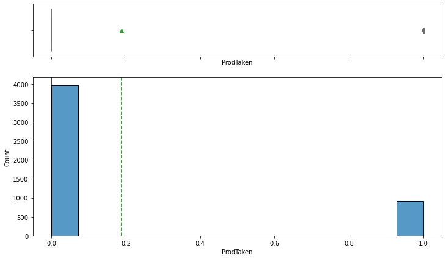

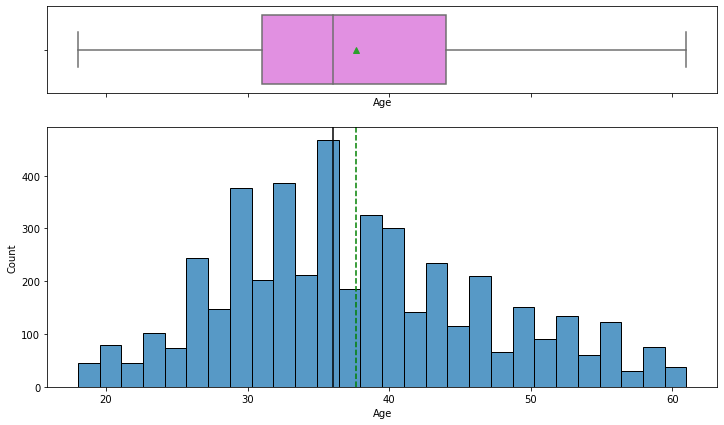

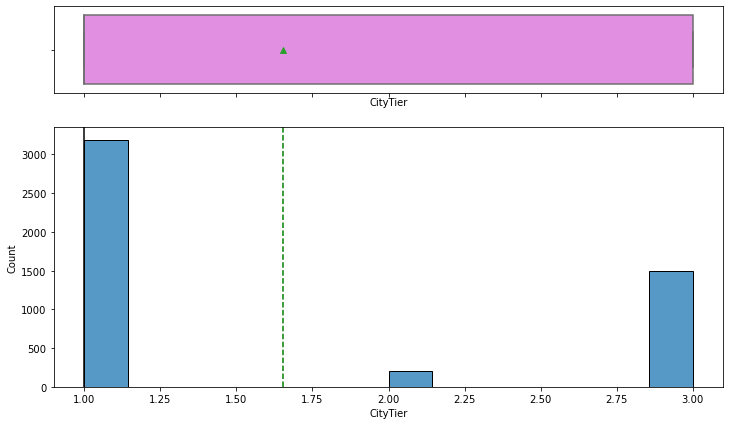

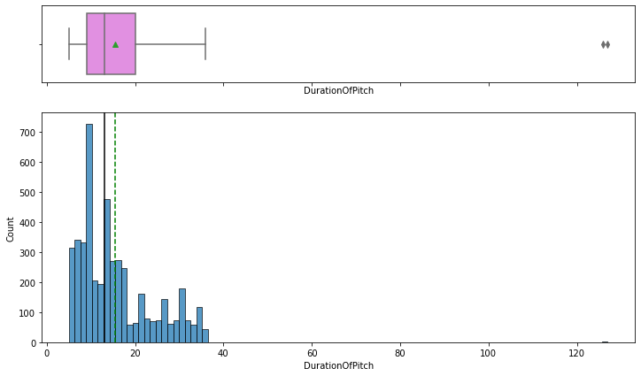

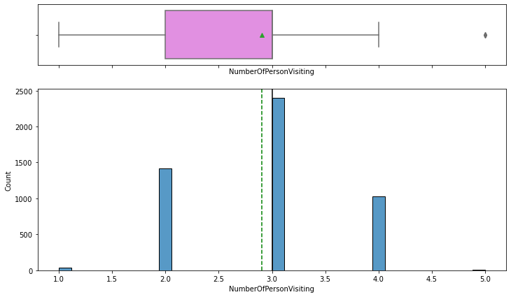

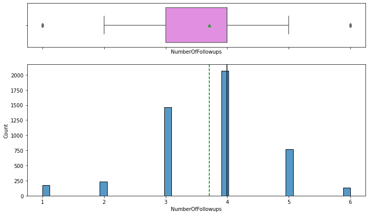

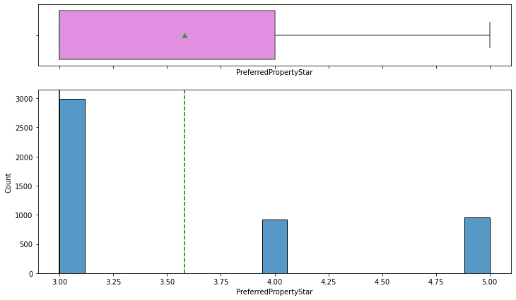

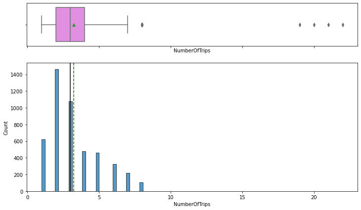

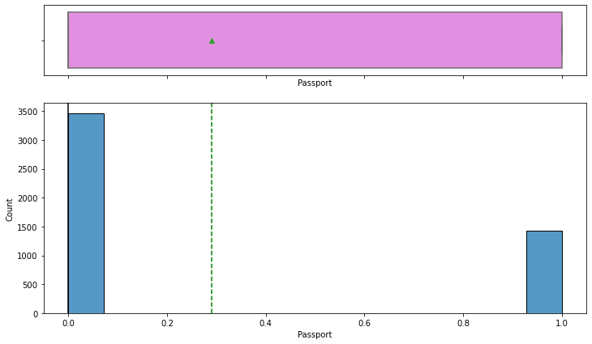

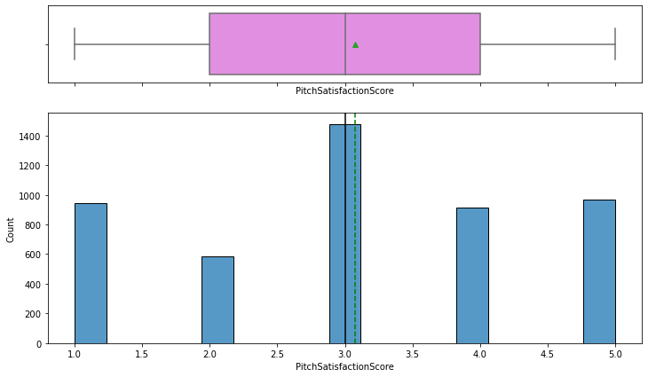

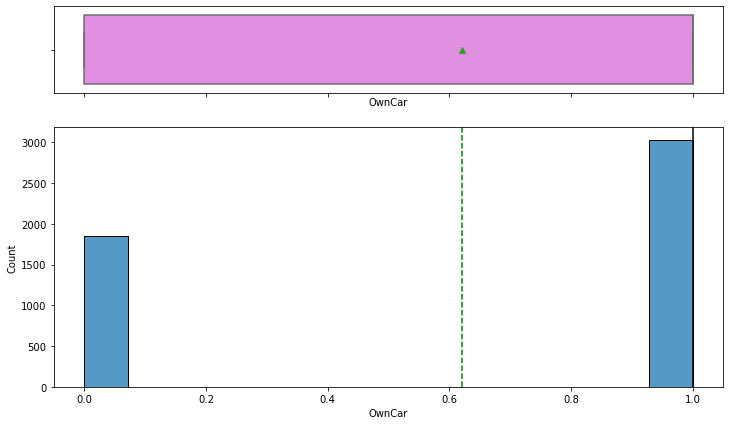

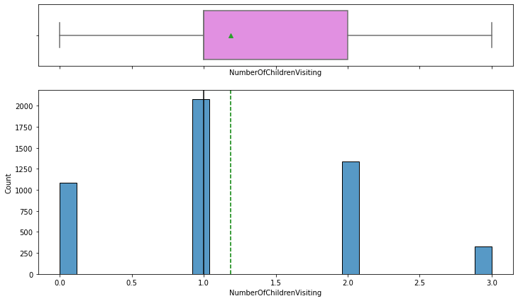

[1 more figures not shown]

```python
#Create to both histgram and boxplot graph for all numerical columns.
for i in num_cols:
    histogram_boxplot(data,i) # Call hist_box function for each column.
```

## Observations on Non-categorical dataset.

- Age dataset is normally distributed without outliers.
- DurationofPitch is more skewed to right and has outliers.
- Number of customers visiting are mostly 3 followed by 2 and 4.
- Number of Trips is right skewed with few outliers.
- MonthlyIncome is right skewed and has outliers.

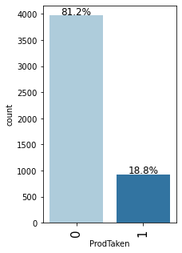

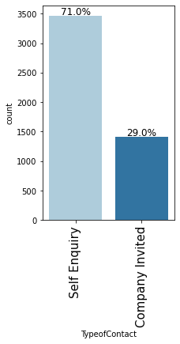

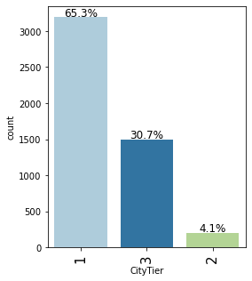

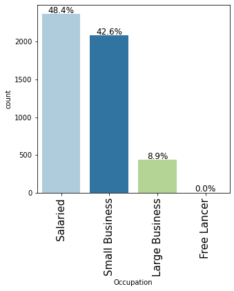

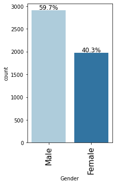

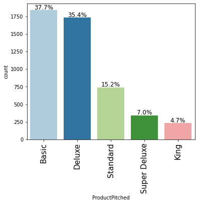

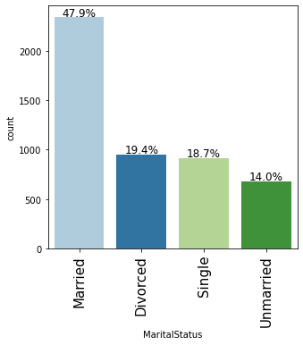

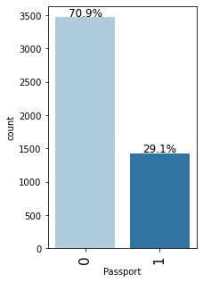

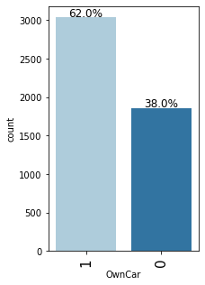

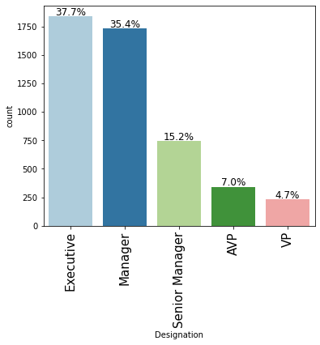

```python
for j in cols_cat:
    cat_bar(data, j, perc=True) # Call hist_box function for each column.
```

## Bivariate Analysis

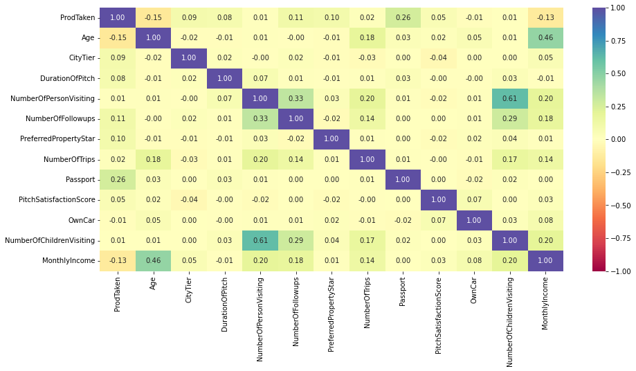

```python
plt.figure(figsize=(15, 7))
sns.heatmap(data.corr(), annot=True, vmin=-1, vmax=1, fmt=".2f", cmap="Spectral")
plt.show()
```

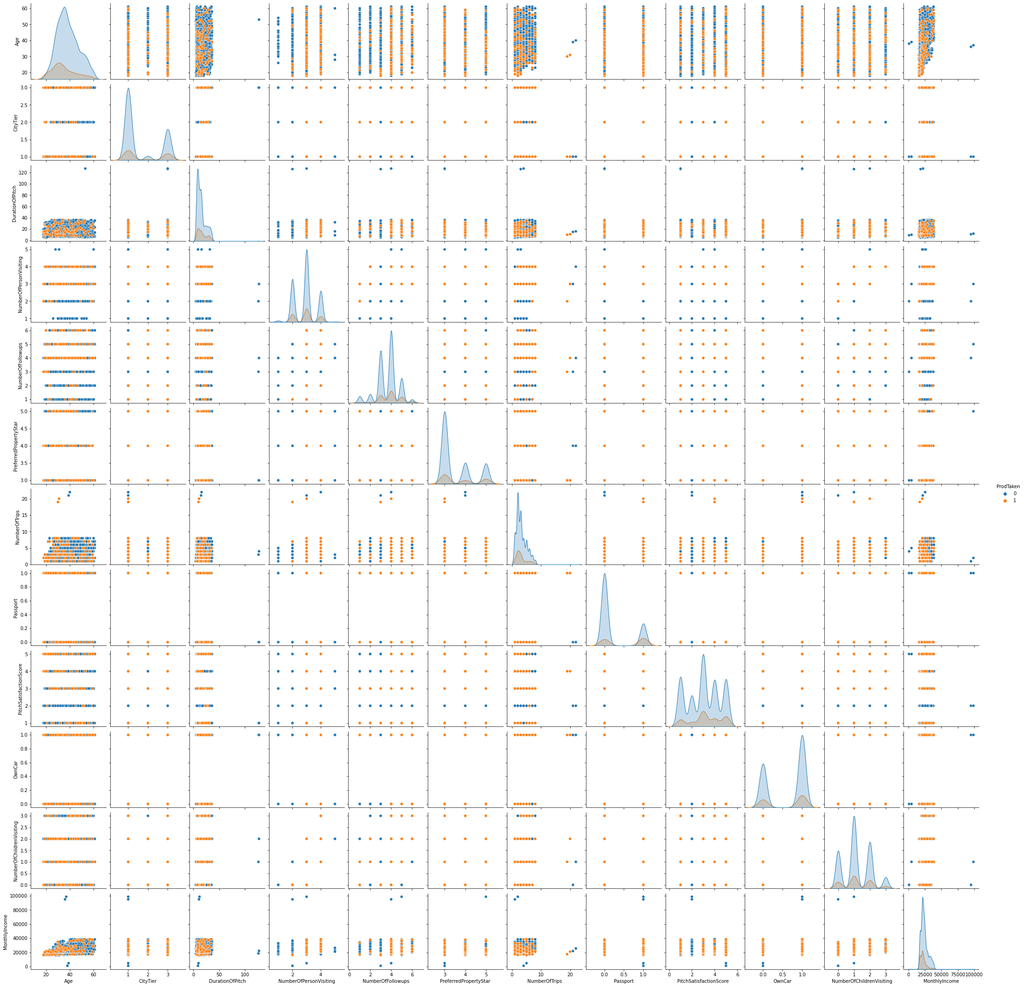

```python
sns.pairplot(data=data, hue="ProdTaken")
plt.show()
```

## Observations

- There is weak correlation between Age and MonthlyIncome.
- There is correlation between NumberofChildren and NumberofPersonVisiting.
- There is weak correlation between NumberOfFollowup and Numberofperson visiting.

```python
data.columns.values.tolist()
```

```
['ProdTaken',
 'Age',
 'TypeofContact',
 'CityTier',
 'DurationOfPitch',
 'Occupation',
 'Gender',
 'NumberOfPersonVisiting',
 'NumberOfFollowups',
 'ProductPitched',
 'PreferredPropertyStar',
 'MaritalStatus',
 'NumberOfTrips',
 'Passport',
 'PitchSatisfactionScore',
 'OwnCar',
 'NumberOfChildrenVisiting',
 'Designation',
 'MonthlyIncome']
```

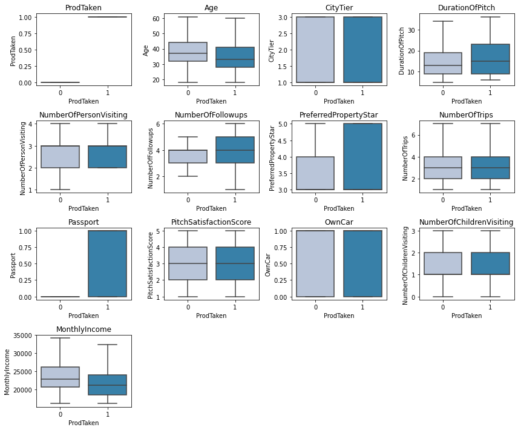

```python
plt.figure(figsize=(12, 12))

for i, variable in enumerate(num_cols):
    plt.subplot(5, 4, i + 1)
    sns.boxplot(data["ProdTaken"], data[variable], palette="PuBu", showfliers=False)
    plt.tight_layout()
    plt.title(variable)
plt.show()
```

```python
# function to plot stacked bar chart


def stacked_barplot(data, predictor, target):
    """
    Print the category counts and plot a stacked bar chart

    data: dataframe
    predictor: independent variable
    target: target variable
    """
    count = data[predictor].nunique()
    sorter = data[target].value_counts().index[-1]
    tab1 = pd.crosstab(data[predictor], data[target], margins=True).sort_values(
        by=sorter, ascending=False
    )
    print(tab1)
    print("-" * 120)
    tab = pd.crosstab(data[predictor], data[target], normalize="index").sort_values(
        by=sorter, ascending=False
    )
    tab.plot(kind="bar", stacked=True, figsize=(count + 5, 6))
    plt.legend(
        loc="lower left", frameon=False,
    )
    plt.legend(loc="upper left", bbox_to_anchor=(1, 1))
    plt.show()
```

```python
print(cat_cols)
```

```
['TypeofContact', 'Occupation', 'Gender', 'ProductPitched', 'MaritalStatus', 'Designation', 'ProdTaken', 'OwnCar', 'Passport', 'CityTier']
```

```
ProdTaken          0    1   All
Occupation
All             3968  920  4888
Salaried        1954  414  2368
Small Business  1700  384  2084
Large Business   314  120   434
Free Lancer        0    2     2
------------------------------------------------------------------------------------------------------------------------
```

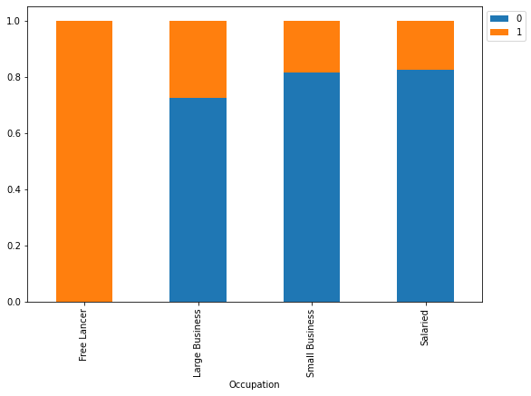

```python
stacked_barplot(data, "Occupation", "ProdTaken")
```

```
ProdTaken     0    1   All
Gender
All        3968  920  4888
Male       2338  578  2916
Female     1630  342  1972
------------------------------------------------------------------------------------------------------------------------
```

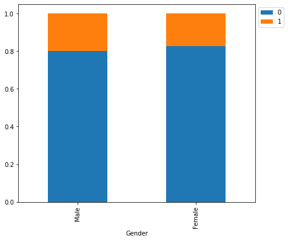

```python
stacked_barplot(data, "Gender", "ProdTaken")
```

```
ProdTaken          0    1   All
ProductPitched
All             3968  920  4888
Basic           1290  552  1842
Deluxe          1528  204  1732
Standard         618  124   742
King             210   20   230
Super Deluxe     322   20   342
------------------------------------------------------------------------------------------------------------------------
```

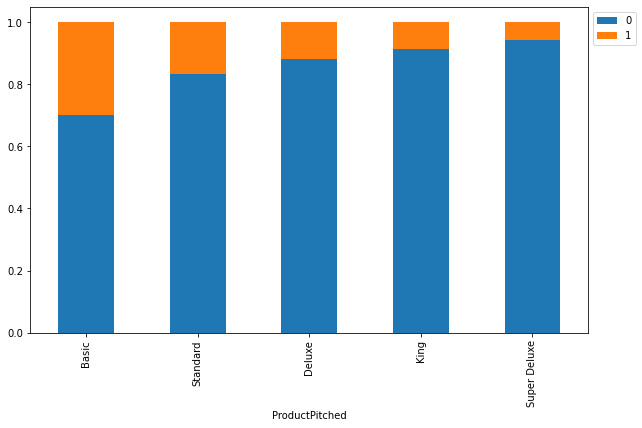

```python
stacked_barplot(data, "ProductPitched", "ProdTaken")
```

```
ProdTaken         0    1   All
MaritalStatus
All            3968  920  4888
Married        2014  326  2340
Single          612  304   916
Unmarried       516  166   682
Divorced        826  124   950
------------------------------------------------------------------------------------------------------------------------
```

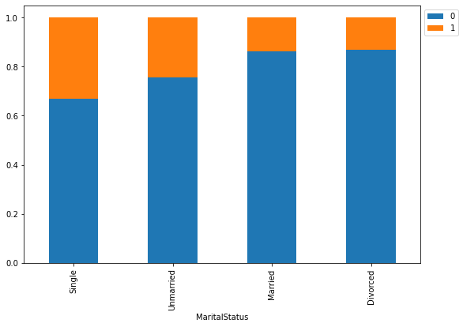

```python
stacked_barplot(data, "MaritalStatus", "ProdTaken")
```

```
ProdTaken          0    1   All
Designation
All             3968  920  4888
Executive       1290  552  1842
Manager         1528  204  1732
Senior Manager   618  124   742
AVP              322   20   342
VP               210   20   230
------------------------------------------------------------------------------------------------------------------------
```

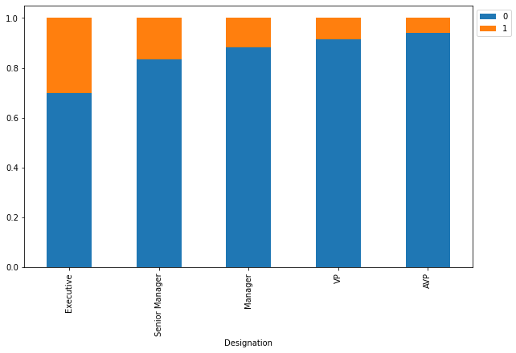

```python
stacked_barplot(data, "Designation", "ProdTaken")
```